# Los Angeles City Council: local ideal points, 2021–2026

Pooled roll-call voting positions

Author

Boris Shor

Updated

October 8, 2026

Los Angeles’s voting spectrum is more revealing within the Democratic coalition than between parties. The DSA-endorsed members occupy the left of the recovered scale, while other Democratic-affiliated members span a much broader range. This report places 24 councilmembers on a shared scale using contested votes from February 2021 through September 2026, then follows the council’s composition across the 2022 and 2024 elections.

**24 members**  
Pooled across 2021–2026

**15 council seats**  
14 observed in the latest council

**624 roll calls**  
Contested council decisions

**7,329 votes**  
Recorded yeas and nays

## Dataset and construction

The analysis uses published roll-call votes from the [MyTown council-votes corpus](https://github.com/MyTownRepo/council-votes), with links back to the city’s official action documents. The preserved national candidate export defines this sample; it is not a claim that every Los Angeles vote or member has been captured.

| Measure | Value |
| --- | --- |
| Coverage | February 16, 2021 – September 11, 2026 |
| Exported member-vote records | 474,559 |
| Keyed actions after cleaning | 44,908 |
| Retained contested actions | 624 |
| Fitted people | 24 |
| Observed yea/nay votes | 7,329 |

We retain votes with at least one member on each side and at least ten recorded yea/nay responses. Members need at least seven such votes. This keeps lone-dissenter votes, which can reveal meaningful differences in a small council, while removing unanimous business and sparsely recorded actions. Absences and unrecorded responses are missing, not opposition. Spelling variants are consolidated; ambiguous name fragments and conflicting responses are excluded rather than guessed.

Only about 1.4% of the cleaned actions qualify. Most recorded council business is unanimous or nearly unanimous; the small retained share primarily reflects selection for disagreement, not loss of all the other records.

**One notable coverage gap:** Tim McOsker has no vote records in this export. The official city account identifies him among the five incoming members in [December 2022](https://cd2.lacity.gov/news/new-city-council-unanimously-elects-krekorian-council-president). Consequently, the latest council plot contains 14 members, not a complete 15-seat council. His omission is an input-data gap, not a low-vote exclusion. No mayoral votes appear in the fitted sample.

## The voting spectrum

An ideal point is a one-dimensional summary of voting similarity. Nearby members tend to take the same side on contested decisions. These are Los Angeles-specific units, not scores directly comparable with another city’s scale. Points show pooled estimates; horizontal lines show their uncertainty.

Shapes distinguish documented DSA and Abundant Housing LA (AHLA) endorsements, including members supported by both. AHLA markers in the pooled plot identify documented 2022 or 2024 support; election-window plots only show support documented by that window. An unmarked member has no endorsement documented here, not necessarily no endorsement historically.

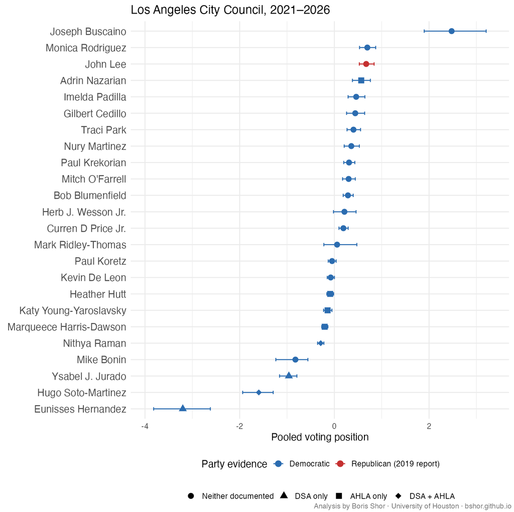

Eunisses Hernandez, Hugo Soto-Martínez and Ysabel Jurado sit toward the left end. Nithya Raman, also DSA-endorsed, is closer to the council’s middle. Joe Buscaino and John Lee sit toward the right. Party labels alone do not capture this spectrum: Buscaino is Democratic-affiliated. Lee is the only fitted member whose sole affiliation label is Republican, based on **historical 2019 reporting**, not verified current registration. Park’s earlier Republican history is retained in the evidence ledger, but she is displayed as Democratic during her observed council service.

### Policy context

The 2023 police-pay agreement passed 12–3; Hernandez, Raman and Soto-Martínez opposed it over budget priorities. [CBS/City News Service](https://www.cbsnews.com/losangeles/news/la-city-council-approves-contract-increasing-pay-of-lapd-officers/)

Buscaino advocated tougher encampment restrictions; Bonin and Raman opposed the 2021 anti-camping ordinance. This supplies policy context for their separation. [Los Angeles Times](https://www.latimes.com/california/story/2021-07-28/anti-camping-vote-la-homelessness)

Monica Rodriguez’s position on the council’s right flank is consistent with three reported votes:

- **Police hiring and the budget, May 22, 2025:** Rodriguez, Lee and Park opposed the revised budget, which advanced 12–3. They argued that it inadequately funded public safety and objected to reducing planned LAPD recruitment from 480 to 240 officers. [City News Service/Spectrum](https://spectrumlocalnews.com/ca/california/politics/2025/05/22/mayor-karen-bass--budget)
- **Tourism-worker wages, May 14, 2025:** Rodriguez, Lee and Park opposed the plan to raise hotel and airport workers’ minimum wage to $30 per hour by 2028; it received preliminary approval, 12–3. Rodriguez and Park also sought different treatment for contracted, variable-hour workers. [City News Service](https://mynewsla.com/business/2025/05/14/la-council-preliminary-approves-wage-increase-for-hotel-and-airport-workers/)
- **Encampment restrictions, August 2026:** Rodriguez, Park and Padilla opposed repealing twelve camping bans; the repeal passed 10–3. [Los Angeles Times](https://www.latimes.com/california/story/2026-08-19/la-city-council-repeals-homeless-camping-bans-in-echo-park-silver-lake-hollywood)

These examples help interpret the endpoints, rather than proving that every contested decision measures the same policy disagreement.

## Councils across elections

The tabs use the same pooled coordinates and horizontal axis. They show members who cast qualifying votes in each election-defined window, including replacements during that window—not separate estimates of how the same person changed over time. Los Angeles members have staggered four-year terms, with council elections every two years ([City Clerk](https://clerk.lacity.gov/elections/municipal-elections/2026-general-information-municipal-candidates)).

**Before the 2022 turnover**

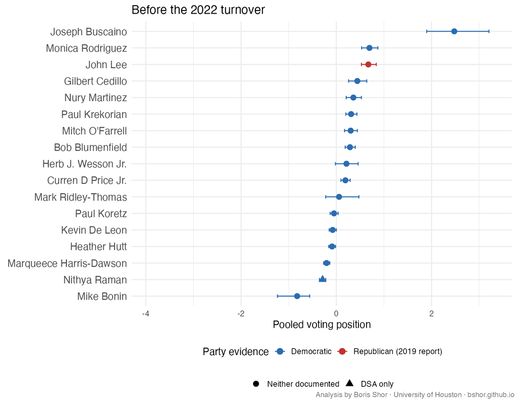

**After the 2022 election**

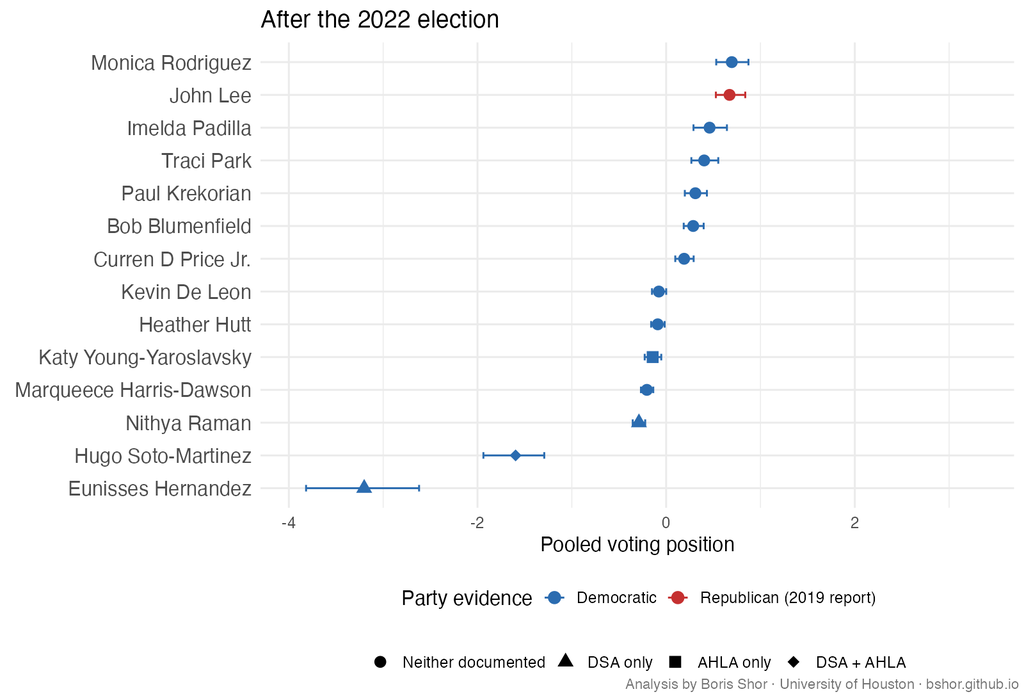

**After the 2024 election**

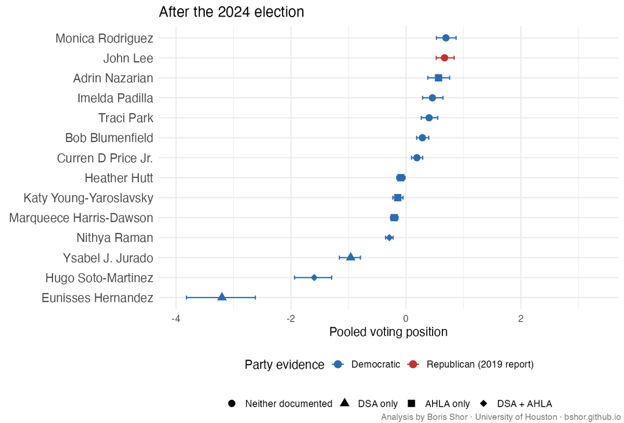

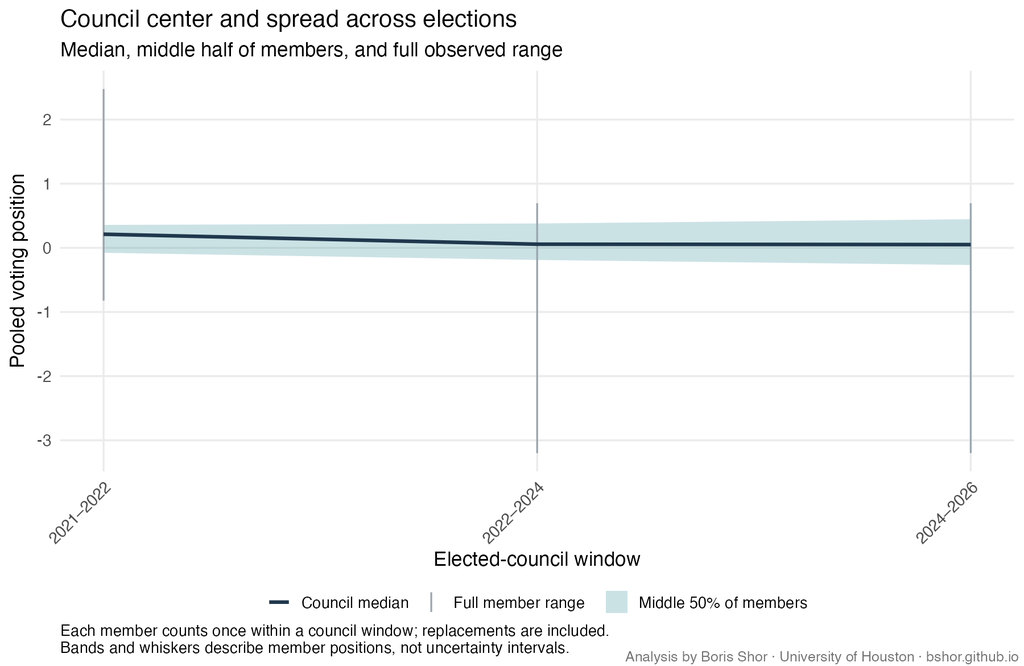

Council medians across election turnovers, with a shaded band for the middle 50% of members and thin whiskers for the full range. These are member distributions, not uncertainty intervals.

The later councils include a larger DSA-endorsed group toward the left. The rest of the membership remains spread across the scale. The missing McOsker record means these distributions describe the observed membership, not the complete council.

## Party evidence and organizational validation

### Party affiliation

| Evidence label | People |
| --- | --- |
| Democratic | 23 |
| Republican — 2019 report | 1 |

Party evidence comes from the researched affiliation ledger, including the [five recent additions](https://github.com/MyTownRepo/council-votes/pull/21). The fifth, Tim McOsker, is Democratic-affiliated but remains outside the fit because his vote records are missing; he is not included in the counts above. Jurado’s Democratic label reflects the county party’s endorsement, not independently verified registration. Park’s September 2022 source says she had already switched to Democratic; her retained council votes begin in January 2023, so she is shown as Democratic without inventing an exact switch date. Lee’s sole Republican claim is dated 2019. With that limited Republican evidence, a two-party comparison would tell us little.

### DSA endorsements

DSA-LA explicitly named Raman, Hernandez and Soto-Martínez as its endorsed councilmembers in [November 2023](https://dsa-la.org/dsa-la-city-councilmember-support-ceasefire/). California DSA documented Jurado’s endorsement and the resulting four-member council group following the [2024 election](https://www.californiadsa.org/news/los-angeles-election-2024). These are organizational indicators, separate from party affiliation. DSA-LA’s **Socialists in Office** program coordinates these officeholders; it is not presented here as a formal City Council caucus or as a second independent validation measure.

The comparisons below use these two documented council groups, not an assumed endorsement census of earlier members. “Other” means the other fitted members of that council window; it does not mean conservative or Republican. The within-Democrat rows ask whether the endorsement measure distinguishes members even after holding the broad party label constant.

| Council group | Comparison | DSA endorsed | Other members | Endorsed median | Other median | Median difference |
| --- | --- | --- | --- | --- | --- | --- |
| After 2022 election | All fitted members | 3 | 11 | -1.60 | 0.29 | -1.88 |
| After 2022 election | Within Democratic-affiliated members | 3 | 10 | -1.60 | 0.24 | -1.83 |
| After 2024 election | All fitted members | 4 | 10 | -1.28 | 0.34 | -1.62 |
| After 2024 election | Within Democratic-affiliated members | 4 | 9 | -1.28 | 0.29 | -1.57 |

In both documented councils, **every DSA-endorsed member’s point estimate is left of every other fitted member’s**, including within the Democratic-affiliated group. At the closest boundary, Raman and Harris-Dawson’s uncertainty intervals slightly overlap. Bonin is also left of Raman in the pooled plot, but he served in the earlier window, for which this report has no complete documented endorsement group.

The comparison describes small groups, not an organization’s causal effect on voting. The endorsed members also differ among themselves; endorsement does not imply a uniform roll-call position.

### Abundant Housing LA endorsements

AHLA supplies a housing-focused comparison distinct from DSA. Its [2022 election update](https://abundanthousingla.org/ahla-endorsed-candidates-update/) identifies Yaroslavsky and Soto-Martínez among its endorsed winners. Its [2024 endorsement list](https://www.abundanthousingla.org/2024-endorsements) includes Raman, Harris-Dawson, Hutt and Nazarian, alongside challengers who are not fitted here. The documented group therefore reaches beyond the DSA bloc.

| AHLA-endorsed member | Election year | Pooled position |
| --- | --- | --- |
| Katy Young-Yaroslavsky | 2022 | -0.14 |
| Hugo Soto-Martinez | 2022 | -1.60 |
| Adrin Nazarian | 2024 | 0.57 |
| Nithya Raman | 2024 | -0.29 |
| Marqueece Harris-Dawson | 2024 | -0.20 |
| Heather Hutt | 2024 | -0.09 |

The comparison below is limited to incoming 2024 members in districts where AHLA documented a candidate choice. “Other” means Lee and Jurado, who are not on the reviewed annual list; it is not a claim that they never received AHLA support. Holdovers and the undocumented District 6 race are excluded. The annual list combines election stages, so this is a descriptive comparison, not one simultaneous endorsement slate.

| Comparison | AHLA endorsed | Other members | Endorsed median | Other median | Median difference |
| --- | --- | --- | --- | --- | --- |
| All fitted members | 4 | 2 | -0.15 | -0.14 | 0.00 |
| Within Democratic-affiliated members | 4 | 1 | -0.15 | -0.96 | 0.81 |

AHLA support is not simply a marker for the council’s leftmost members: its endorsed group spans Raman through Nazarian. The within-Democrat comparison has only one other member, Jurado, so it should be read as a small-group description.

## Interpretation and limits

This is a scale of recorded disagreement, not all council activity. It pools each member’s votes into one position and cannot by itself show individual ideological movement. Source-backed affiliations help describe the spectrum, but some labels are dated observations rather than continuous histories. The missing McOsker records and excluded parser fragments limit coverage; fuller inputs could change estimates.

Unlike the other city reports, LA does not yet have district-level presidential or mayoral election validation; that is a later addition to this pilot.

Estimation, diagnostics, evidence construction and the extraction audit are in the technical appendix.